# Capstone Project - Milestone Report

Daniel F. Moore

Monday, November 10, 2014

# Summary

The goal of this document is to show the data acqusition, summary statistics about the data sets, exploratory analysis, and outline plans for the prediction algorithm and Shiny app that is planned for the final product.

## Load packages

```r
#load some libraries
library(plyr)
library(reshape2)
library(tm) #Text mining
```

```r
library(SnowballC) #Provides wordStem()
library(RColorBrewer) #color palette
library(ggplot2)
library(magrittr)
library(Rgraphviz) #from bioconductor 0 install via - source("http://bioconductor.org/biocLite.R");biocLite("Rgraphviz")
library(wordcloud)
library(RWeka) # for doing the bigrams
## Reading in as a corpus
workingdir<-paste("C:\\Users", Sys.getenv("USERNAME"), "Documents\\GitHub\\DataScienceCapstone", sep = "\\")
setwd(workingdir)
```

The basic acquiring, importing, and cleaning of the data involves several steps.

1. Load and Subset the data - The data is imported into R in a format that makes text mining and analysis possible. In this case, we are using a Corpus to combine the English data from news sites, blogs, and twitter as contained in the Swiftkey data set.
2. Tidy up the text - The data is cleaned up of punctuation, made all lower case, numbers are removed, and swear words are removed.
3. Transform data into structured format - The data is transformed into the structured format that will actually be computed with - for this task, we use a *document-term matrix*.

Then, finally, we will get a first look at the data.

To begin, let’s load the data up and we’ll sample it down - it’s way to big to use the whole dataset in our analysis

# Load, Tidy, and Structure the Data

## Load Data and Subset it

```r
cname<-file.path(".", "final", "en_US")

sparsity<-0.2
docs<- Corpus(DirSource(cname))

print("Blog file stats: ")
```

```
## [1] "Blog file stats: "
```

```r
print(paste("Length:",as.character(length(docs[[1]]$content)), sep=" "))
```

```
## [1] "Length: 899288"
```

```r
print(paste("Sample data:",as.character(head(docs[[1]]$content,1)), sep=" "))
```

```
## [1] "Sample data: In the years thereafter, most of the Oil fields and platforms were named after pagan â€œgodsâ€."
```

```r
print("News file stats: ")
```

```
## [1] "News file stats: "
```

```r
print(paste("Length:",as.character(length(docs[[2]]$content)), sep=" "))
```

```
## [1] "Length: 77259"
```

```r
print(paste("Sample data:",as.character(head(docs[[2]]$content,1)), sep=" "))
```

```
## [1] "Sample data: He wasn't home alone, apparently."
```

```r
print("Twitter file stats: ")
```

```
## [1] "Twitter file stats: "
```

```r
print(paste("Length:",as.character(length(docs[[3]]$content)), sep=" "))
```

```
## [1] "Length: 2360148"
```

```r
print(paste("Sample data:",as.character(head(docs[[3]]$content,1)), sep=" "))
```

```
## [1] "Sample data: How are you? Btw thanks for the RT. You gonna be in DC anytime soon? Love to see you. Been way, way too long."
```

```r
#sample docs first
perc_sampling = 0.1
docs[[1]]$content<-sample(docs[[1]]$content, length(docs[[1]]$content)*perc_sampling)
docs[[2]]$content<-sample(docs[[2]]$content, length(docs[[2]]$content)*perc_sampling*5)
docs[[3]]$content<-sample(docs[[3]]$content, length(docs[[3]]$content)*perc_sampling*0.4)
```

## Tidy the Text

The next step is to tidy up the text. I’m using the *tm* package for text mining and tidying. We are going to do a few transformations including converting special characters (other than apostrophes and hyphens) into spaces, making everything lower case, removing numbers, removing other punctuation, and stripping out whitespace. I’m intentionally not removing stopwords, as we want to predict them, nor am I *stemming* the words as I want to distinguish between different word endings. I am also removing a few swear words.

```r
toSpace <- content_transformer(function(x, pattern) gsub(pattern, " ", x)) # create function that will let us convert things to a space
toRemove <- content_transformer(function(x, pattern) gsub(pattern, "", x)) # create function that will let us remove characters - such as apostrophes
docs<-tm_map(docs, toSpace, "/|@|\\|#~!@#$%^&*()_+:<>?,./;\"") # this will convert special characters (except apostrophe and hyphen) to a space in all the docs in the corpus
docs<-tm_map(docs, content_transformer(tolower)) # lower case everything
docs<-tm_map(docs, removeNumbers) # Remove the numbers
docs<-tm_map(docs, removePunctuation) # Remove punctuation
docs<-tm_map(docs, stripWhitespace) # Strip out the whitespace
#docs<-tm_map(docs, stemDocument) # this will remove common word endings for English words, such as es, ed, and s, and ing
#docs<-tm_map(docs, removeWords, stopwords("english")) # remove stopwords (do this because of exploration)
docs<-tm_map(docs, removeWords, c("fuck", "shit", "cock", "ass")) #remove other words
```

## Structure the data

The third step is to structure the data - and save it for further analysis (these three steps can take a *very long time*). As mentioned above, we’re going to save the data in a corpus as a document term matrix. This is a matrix that is used to describe the frequency of terms that occur in document collections. We are going to create four different document term matrices. One has each single word as a term, the second has each bigram, the third has each trigram, and the fourth has each quadgram as a term. All of these are then saved in a corpus for saving and retrieving.

```r
corpus<-c()
corpus$docs<-docs

dtm<-DocumentTermMatrix(docs) ## This does the tokenizing
corpus$dtmonegrams<-removeSparseTerms(dtm, sparsity)

BigramTokenizer<-function(x) NGramTokenizer(x, Weka_control(min=2, max=2))
dtm_bigram<-DocumentTermMatrix(docs, control=list(tokenize=BigramTokenizer))
corpus$dtmbigrams<-removeSparseTerms(dtm_bigram, sparsity)

TrigramTokenizer<-function(x) NGramTokenizer(x, Weka_control(min=3, max=3))
dtm_trigram<-DocumentTermMatrix(docs, control=list(tokenize=TrigramTokenizer))
corpus$dtmtrigrams<-removeSparseTerms(dtm_trigram, sparsity)

quadgramTokenizer<-function(x) NGramTokenizer(x, Weka_control(min=4, max=4))
dtm_quadgram<-DocumentTermMatrix(docs, control=list(tokenize=quadgramTokenizer))
corpus$dtmquadgrams<-removeSparseTerms(dtm_quadgram, sparsity)

saveRDS(corpus, file="corpus.rds")
```

# A First Look

To get a first look at the data, let’s look at each of the document term matrices in turn.

## Mono-grams

```r
if(!exists("corpus")) corpus<-readRDS("corpus.rds") # if it isn't loaded, then read the corpus in
dtm<-corpus$dtmonegrams
dtm_bigram<-corpus$dtmbigrams
dtm_trigram<-corpus$dtmtrigrams
dtm_quadgram<-corpus$dtmquadgrams
##Plot Word Frequencies
freq<-sort(colSums(as.matrix(dtm)), decreasing=TRUE)
head(freq, 14)
```

```
##    the    and   that    for    you   with    was   this   have    are
## 296182 159138  67453  65010  54828  45243  41024  36720  33595  30978
##    but    not   from    all
##  30490  26147  23928  21696
```

```r
wf<-data.frame(word=names(freq), freq=freq)
head(wf)
```

```
##      word   freq
## the   the 296182
## and   and 159138
## that that  67453
## for   for  65010
## you   you  54828
## with with  45243
```

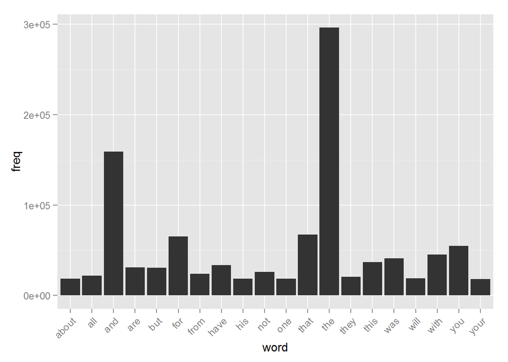

```r
subset(wf, freq>head(freq,20)[20]-1) %>%
    ggplot(aes(word, freq)) +
    geom_bar(stat="identity") +
    theme(axis.text.x=element_text(angle=45, hjust=1))
```

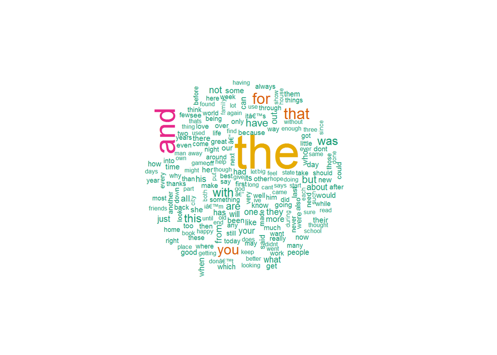

```r
## Do word cloud
set.seed(123)
wordcloud(names(freq), freq, max.words=200, colors=brewer.pal(6, "Dark2"), rot.per=0.2)
```

## Bigrams

```r
##Plot Word freq_bigramuencies
freq_bigram<-sort(colSums(as.matrix(dtm_bigram)), decreasing=TRUE)
head(freq_bigram, 14)
```

```
##   of the   in the   to the   on the  for the    to be   at the  and the
##    27907    25169    13360    12157    11603    10479     8433     8416
##     in a with the     is a   it was    i was   i have
##     7513     6897     6696     6490     6375     6158
```

```r
wf_bigram<-data.frame(word=names(freq_bigram), freq_bigram=freq_bigram)
bigramsplit<-cbind(wf_bigram, colsplit(wf_bigram$word, " ", c("startstate", "endstate")))

head(wf_bigram)
```

```
##            word freq_bigram
## of the   of the       27907
## in the   in the       25169
## to the   to the       13360
## on the   on the       12157
## for the for the       11603
## to be     to be       10479
```

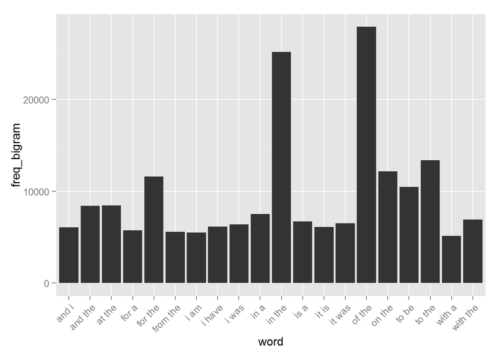

```r
subset(wf_bigram, freq_bigram>head(freq_bigram,20)[20]-1) %>%
    ggplot(aes(word, freq_bigram)) +
    geom_bar(stat="identity") +
    theme(axis.text.x=element_text(angle=45, hjust=1))
```

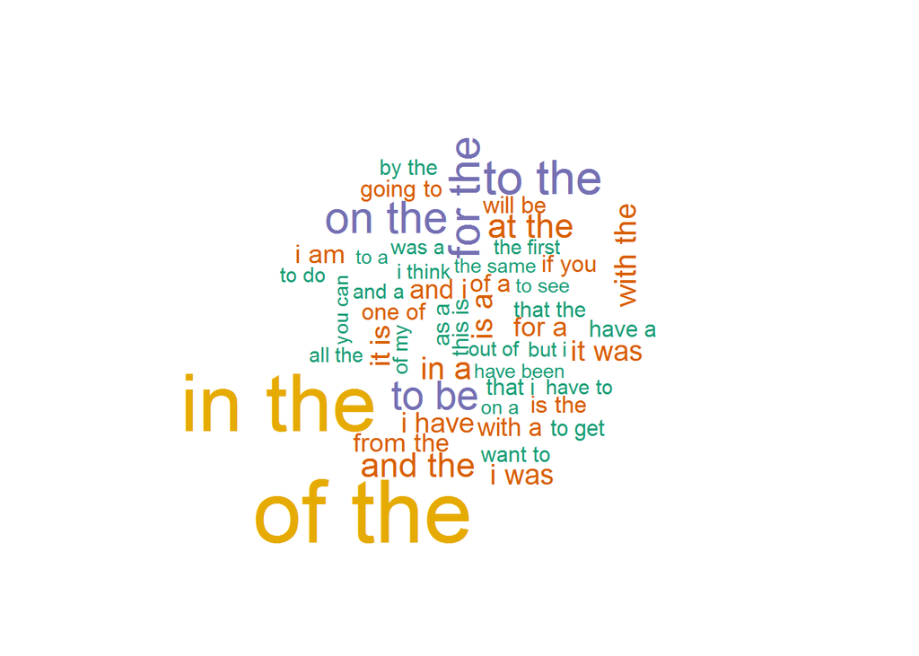

```r
## Do word cloud
set.seed(123)
wordcloud(names(freq_bigram), freq_bigram, max.words=50, colors=brewer.pal(6, "Dark2"), rot.per=0.2)
```

## Trigrams

```r
##Plot Word freq_trigramuencies
freq_trigram<-sort(colSums(as.matrix(dtm_trigram)), decreasing=TRUE)
head(freq_trigram, 14)
```

```
##     one of the       a lot of        to be a    going to be      i want to
##           2239           1872           1118           1025           1010
## thanks for the     as well as     the end of    some of the       it was a
##            973            956            942            933            932
##     out of the     be able to       i have a    part of the
##            908            891            764            759
```

```r
wf_trigram<-data.frame(word=names(freq_trigram), freq_trigram=freq_trigram)

trigramsplit<-cbind(wf_trigram, colsplit(wf_trigram$word, " ", c("word1", "word2", "endstate")))
trigramsplit$startstate<-paste(trigramsplit$word1, trigramsplit$word2, sep=" ")
head(wf_trigram)
```

```
##                          word freq_trigram
## one of the         one of the         2239
## a lot of             a lot of         1872
## to be a               to be a         1118
## going to be       going to be         1025
## i want to           i want to         1010
## thanks for the thanks for the          973
```

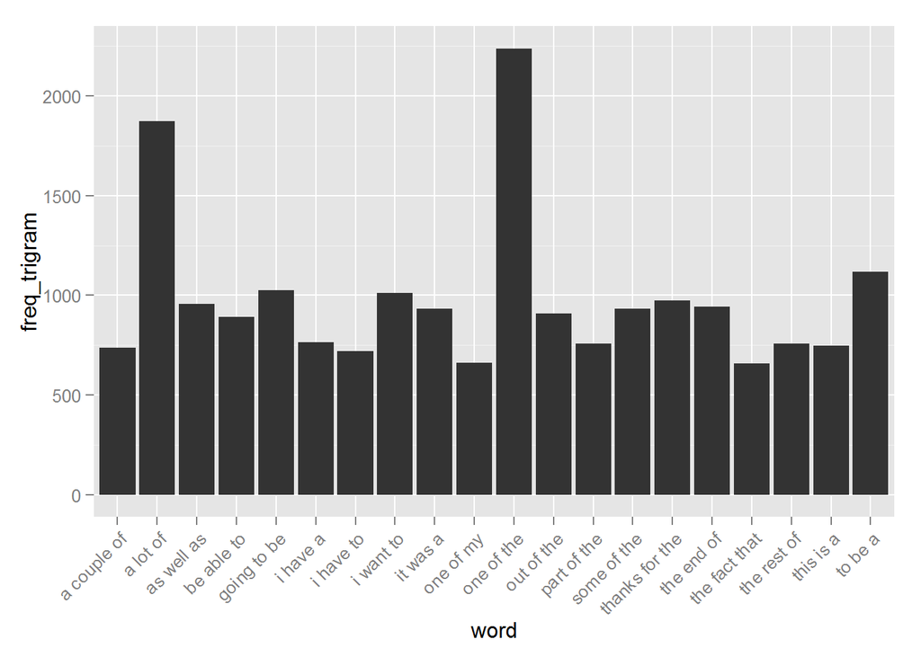

```r
subset(wf_trigram, freq_trigram>head(freq_trigram,20)[20]-1) %>%
    ggplot(aes(word, freq_trigram)) +
    geom_bar(stat="identity") +
    theme(axis.text.x=element_text(angle=45, hjust=1))
```

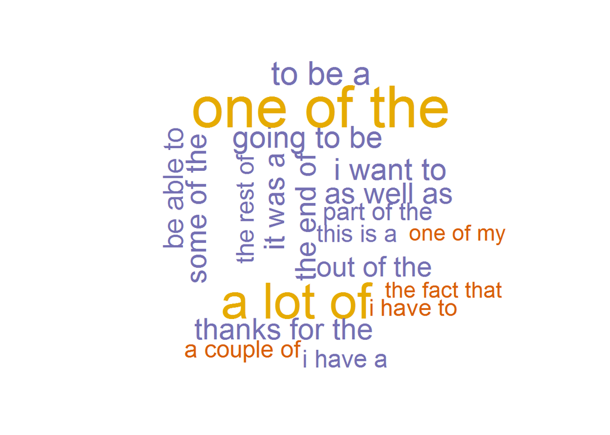

```r
## Do word clouds
set.seed(123)
wordcloud(names(freq_trigram), freq_trigram, max.words=20, colors=brewer.pal(6, "Dark2"), rot.per=0.2)
```

## Quadgrams

```r
freq_quadgram<-sort(colSums(as.matrix(dtm_quadgram)), decreasing=TRUE)
head(freq_quadgram, 14)
```

```
##     the end of the      at the end of    the rest of the
##                477                458                451
## for the first time   at the same time   when it comes to
##                389                343                297
##      is one of the    one of the most   in the middle of
##                285                280                270
##      to be able to     is going to be     if you want to
##                245                237                235
##      i am going to      going to be a
##                201                192
```

```r
wf_quadgram<-data.frame(word=names(freq_quadgram), freq_quadgram=freq_quadgram)
quadgramsplit<-cbind(wf_quadgram, colsplit(wf_quadgram$word, " ", c("word1", "word2", "word3", "endstate")))
quadgramsplit$startstate<-paste(quadgramsplit$word1, quadgramsplit$word2, quadgramsplit$word3, sep=" ")
head(wf_quadgram)
```

```
##                                  word freq_quadgram
## the end of the         the end of the           477
## at the end of           at the end of           458
## the rest of the       the rest of the           451
## for the first time for the first time           389
## at the same time     at the same time           343
## when it comes to     when it comes to           297
```

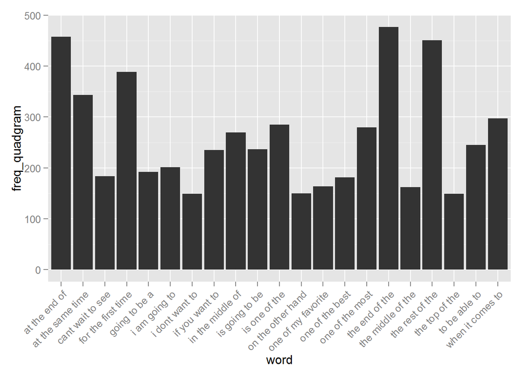

```r
subset(wf_quadgram, freq_quadgram>head(freq_quadgram,20)[20]-1) %>%
    ggplot(aes(word, freq_quadgram)) +
    geom_bar(stat="identity") +
    theme(axis.text.x=element_text(angle=45, hjust=1))
```

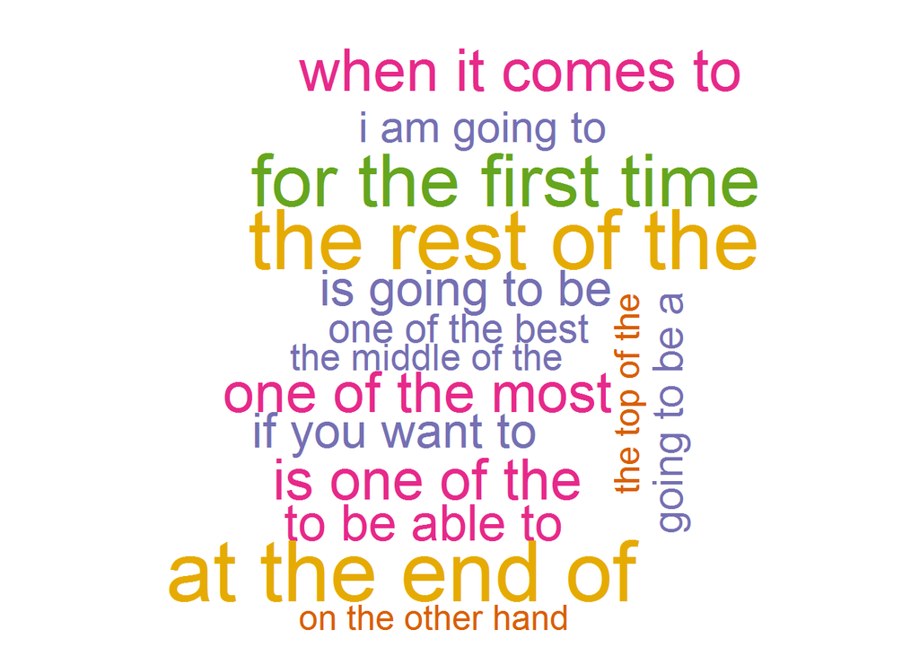

```r
## Do word clouds
set.seed(123)
wordcloud(names(freq_quadgram), freq_quadgram, max.words=20, colors=brewer.pal(6, "Dark2"), rot.per=0.2)
```

# Next Steps

The next step is to build a model and application where, given a one, two, or three word phrase, the next word in the phrase will be predicted. For example, given the input phrase *“the end of”*, we want to return *“the”* as the most likely fourth word in the phrase (“the end of the” is the most common reported quadgram that begins with the trigram “the end of”).

If an unrecognized 3 word phrase is put in, then the last two words will be used to see what the most common third word following those two is. If that two word phrase is unrecognized, then the last word will be used to see what the most common second word following that one word is. If none of the words are recognized, then the model will output the most common single word.